# Прогнозирование заказов такси

## Описание проекта

**Цель проекта**

Компания такси собрала исторические данные о заказах такси в аэропортах. Чтобы привлекать больше водителей в период пиковой нагрузки, нужно спрогнозировать количество заказов такси на следующий час и построить модель для такого предсказания.

Значение метрики *RMSE* на тестовой выборке должно быть не больше 48.

**Исходные данные**

Компания-заказчик предоставила файл `taxi.csv` со следующими данными:

- `num_orders` — число заказов (целевой признак).

**Этапы проекта**

Решать поставленную задачу будем в следующем порядке:

1. Загрузим данные и выполним их ресемплирование по одному часу.
2. Проанализируем данные.
3. Обучим разные модели с различными гиперпараметрами. Сделаем тестовую выборку размером 10% от исходных данных.
4. Проверим данные на тестовой выборке и сделаем выводы.

## Загрузка данных

### Подготовка библиотек и загрузка данных

```python
## импортируем необходимые библиотеки----------------------------------------------------
import pandas as pd
import matplotlib.pyplot as plt
import warnings

## из библиотек импортируем необходимые функции и классы---------------------------------
from math import sqrt

# загружаем функции
from sklearn.model_selection import train_test_split
from statsmodels.tsa.seasonal import seasonal_decompose
from statsmodels.tsa.stattools import adfuller

# загружаем инструменты для автоподбора гиперпараметров
from sklearn.model_selection import (
    RandomizedSearchCV,
    TimeSeriesSplit
)

# загружаем классы моделей
from sklearn.tree import DecisionTreeRegressor
from sklearn.linear_model import LinearRegression
from lightgbm import LGBMRegressor

# загружаем класс для работы с пайплайнами
from sklearn.pipeline import Pipeline

# загружаем метрики
from sklearn.metrics import (
    mean_squared_error,
)

# загружаем классы для преобразования данных
from sklearn.preprocessing import (
    StandardScaler,
    MinMaxScaler,
)

from sklearn.compose import ColumnTransformer

## константы----------------------------------------------------------------------------

# константа для фиксации данных при обучении моделей, чтобы получать одинаковые результаты при пересчёте
RANDOM_STATE = 42

# размер тестовой выборки
TEST_SIZE = 0.1

## настройки----------------------------------------------------------------------------

# скрываем предупреждения
warnings.filterwarnings('ignore')
```

Cоздадим датафрейм `df` из файла `taxi.csv`.

```python
# загружаем данные заказчика
df = pd.read_csv('taxi.csv', index_col=[0], parse_dates=[0])
```

- Данные загружены в датафрейм.
- Ошибок не обнаружено.

### Получение общей информации о данных

Выведем первые строки созданного датафрейма и общую информацию.

```python
# выведем первые строки датафрейма
df.head()
```

| datetime | num_orders |
| --- | --- |
| 2018-03-01 00:00:00 | 9 |
| 2018-03-01 00:10:00 | 14 |
| 2018-03-01 00:20:00 | 28 |
| 2018-03-01 00:30:00 | 20 |
| 2018-03-01 00:40:00 | 32 |

```python
# проверим, соблюден ли порядок дат
df.index.is_monotonic
```

```
True
```

Порядок соблюдён, дополнительных действий не требуется.

```python
# выведем общую информацию
df.info()
```

```
<class 'pandas.core.frame.DataFrame'>
DatetimeIndex: 26496 entries, 2018-03-01 00:00:00 to 2018-08-31 23:50:00
Data columns (total 1 columns):
 #   Column      Non-Null Count  Dtype
---  ------      --------------  -----
 0   num_orders  26496 non-null  int64
dtypes: int64(1)
memory usage: 414.0 KB
```

**Вывод:**

Данные представлены временным рядом с датами наблюдений:

- от `2018-03-01 00:00:00` до `2018-08-31 23:50:00` включительно.
- Пропусков нет.
- Порядок дат соблюдён.
- Типы данных корректны.

Предобработка данных не требуется. Необходимо проверить данные на аномалии в ходе исследовательского анализа.

## Исследовательский анализ данных

Ресемплируем временной ряд по одному часу и проанализируем данные.

```python
# ресемплируем данные по одному часу, суммируя значения
resample_hour = df.resample('1H').sum()
```

```python
resample_hour.index.is_monotonic
```

```
True
```

```python
resample_hour.info()
```

```
<class 'pandas.core.frame.DataFrame'>
DatetimeIndex: 4416 entries, 2018-03-01 00:00:00 to 2018-08-31 23:00:00
Freq: H
Data columns (total 1 columns):
 #   Column      Non-Null Count  Dtype
---  ------      --------------  -----
 0   num_orders  4416 non-null   int64
dtypes: int64(1)
memory usage: 69.0 KB
```

Ресемплинг прошел корректно. Имеем 4416 часов наблюдений с суммарным числом заказов такси по каждому часу.

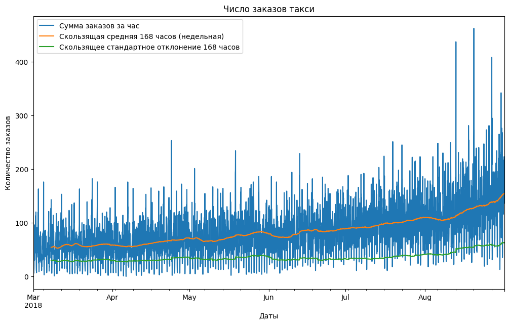

```python
# построим недельную скользящую среднюю
resample_hour['rolling_mean_168'] = resample_hour.rolling(168, closed='left').mean()

# построим скользящее стандартное отклонение
resample_hour['std_168'] = resample_hour['num_orders'].rolling(168, closed='left').std()

# построим график
resample_hour.plot()
plt.title('Число заказов такси')
plt.xlabel('Даты')
plt.ylabel('Количество заказов')
plt.legend(['Сумма заказов за час',
            'Скользящая средняя 168 часов (недельная)',
            'Скользящее стандартное отклонение 168 часов'])

fig = plt.gcf()            # увеличиваем размеры графика
fig.set_size_inches(12, 7) # увеличиваем размеры графика

plt.show()
```

- Недельная скользящая средняя показывает восходящий тренд - сумма заказов за час растёт. С августа наблюдаем ускорение - квадратичный тренд.
- Недельное стандартное отклонение растёт, дисперсия непостоянна.

Чтобы проверить, является ли временной ряд стационарным, проведем расширенный тест Дики-Фуллера:

- Ho (нулевая гипотеза): данные временных рядов нестационарны.
- H1 (альтернативная гипотеза): данные временных рядов являются стационарными.

```python
# сохраняем количество заказов в переменную values
values = resample_hour['num_orders']

# передаем количество заказов в функцию adfuller
res = adfuller(values)

# печатаем статистические результаты
print('Augmneted Dickey_fuller Statistic: %f' % res[0])
print('p-value: %f' % res[1])

# печатаем критические значения на разных альфа-уровнях
print('critical values at different levels:')
for k, v in res[4].items():
    print('\t%s: %.3f' % (k, v))

# передаем в функцию уровень значимости alpha и p-value
# получаем вывод по проверке гипотезы
def alpha_pvalue(alpha, p_value):
    if p_value >= alpha:
        print(f'\nПри уровне значимости {alpha*100}% мы не можем отклонить нулевую гипотезу:')
        print(f'c достоверностью {(1-alpha)*100}% временной ряд является нестационарным.')
    if p_value < alpha:
        print(f'\nПри уровне значимости {alpha*100}% отклоним нулевую гипотезу в пользу альтернативной:')
        print(f'c достоверностью {(1-alpha)*100}% временной ряд является стационарным.')

alpha_pvalue(0.01, res[1])
alpha_pvalue(0.05, res[1])
alpha_pvalue(0.10, res[1])
```

```
Augmneted Dickey_fuller Statistic: -3.068924
p-value: 0.028940
critical values at different levels:
	1%: -3.432
	5%: -2.862
	10%: -2.567

При уровне значимости 1.0% мы не можем отклонить нулевую гипотезу:
c достоверностью 99.0% временной ряд является нестационарным.

При уровне значимости 5.0% отклоним нулевую гипотезу в пользу альтернативной:
c достоверностью 95.0% временной ряд является стационарным.

При уровне значимости 10.0% отклоним нулевую гипотезу в пользу альтернативной:
c достоверностью 90.0% временной ряд является стационарным.
```

```python
# разложим временнной ряд на тренд и сезонность
decomposed = seasonal_decompose(resample_hour['num_orders'])
```

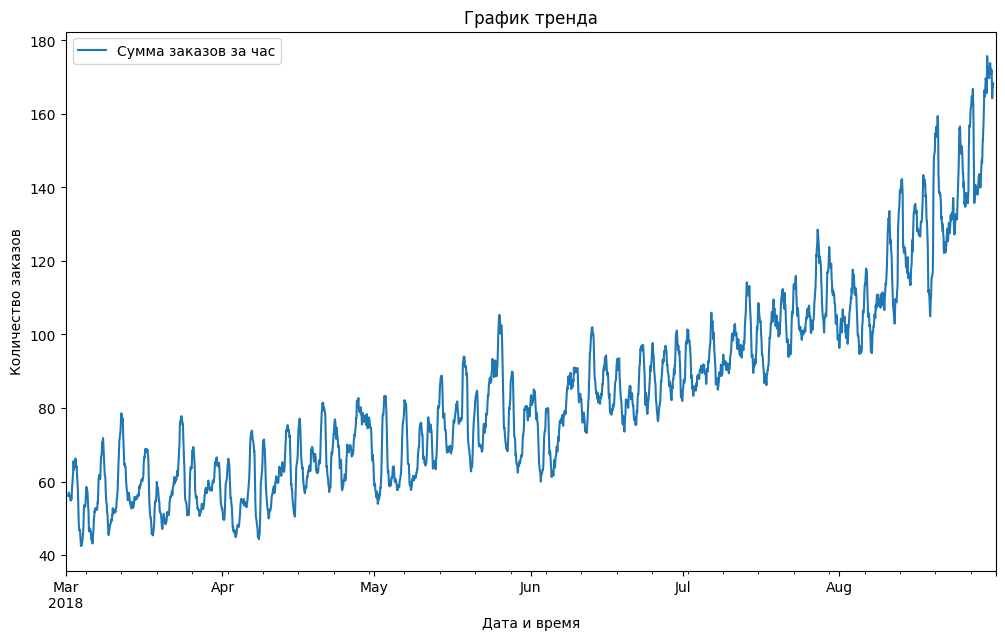

```python
decomposed.trend.plot()
plt.title('График тренда')
plt.xlabel('Дата и время')
plt.ylabel('Количество заказов')
plt.legend(['Сумма заказов за час'])

fig = plt.gcf()            # увеличиваем размеры графика
fig.set_size_inches(12, 7) # увеличиваем размеры графика
plt.show()
```

Есть ярко выраженный тренд роста заказов.

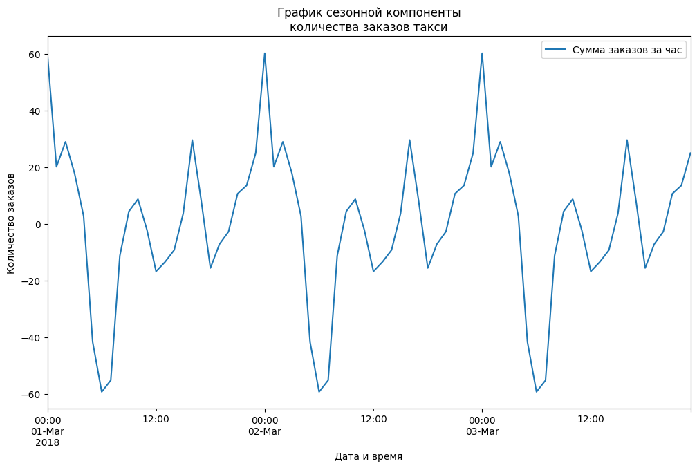

```python
decomposed.seasonal['2018-03-01':'2018-03-03'].plot()
plt.title('График сезонной компоненты\nколичества заказов такси')
plt.xlabel('Дата и время')
plt.ylabel('Количество заказов')
plt.legend(['Сумма заказов за час'])

fig = plt.gcf()            # увеличиваем размеры графика
fig.set_size_inches(12, 7) # увеличиваем размеры графика
plt.show()
```

Максимальное число заказов наблюдается в полночь, далее спад примерно до 6 часов утра.

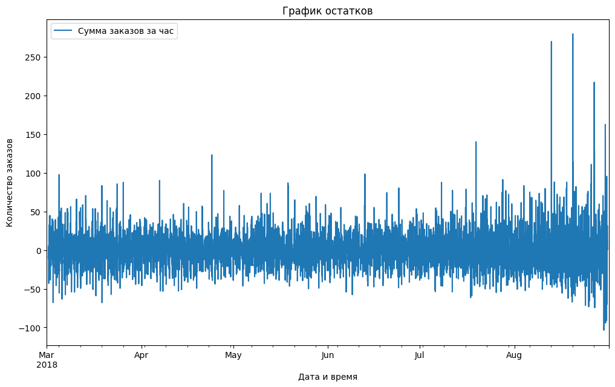

```python
decomposed.resid.plot()
plt.title('График остатков')
plt.xlabel('Дата и время')
plt.ylabel('Количество заказов')
plt.legend(['Сумма заказов за час'])

fig = plt.gcf()            # увеличиваем размеры графика
fig.set_size_inches(12, 7) # увеличиваем размеры графика
plt.show()
```

Наблюдаем возрастание дисперсии распределения остатков с августа.

Для более глубокого изучения временного ряда выполним ресемплирование по дням, сохраним как датафрейм `resample_day`.

```python
# ресемплируем данные по одному дню
resample_day = df.resample('1D').sum()
```

```python
# проверим, соблюдён ли порядок дат
resample_day.index.is_monotonic
```

```
True
```

```python
# выведем общую информацию о датафрейме
resample_day.info()
```

```
<class 'pandas.core.frame.DataFrame'>
DatetimeIndex: 184 entries, 2018-03-01 to 2018-08-31
Freq: D
Data columns (total 1 columns):
 #   Column      Non-Null Count  Dtype
---  ------      --------------  -----
 0   num_orders  184 non-null    int64
dtypes: int64(1)
memory usage: 2.9 KB
```

Ресемплинг прошел корректно. Имеем 184 дня наблюдений с суммарным числом заказов такси по каждому дню.

```python
# разложим временнной ряд на тренд и сезонность
decomposed_day = seasonal_decompose(resample_day['num_orders'])
```

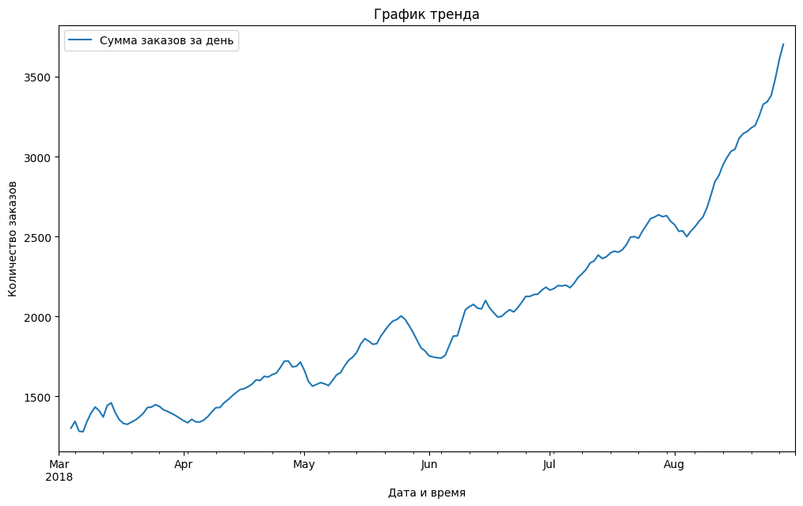

```python
decomposed_day.trend.plot()
plt.title('График тренда')
plt.xlabel('Дата и время')
plt.ylabel('Количество заказов')
plt.legend(['Сумма заказов за день'])

fig = plt.gcf()            # увеличиваем размеры графика
fig.set_size_inches(12, 7) # увеличиваем размеры графика
plt.show()
```

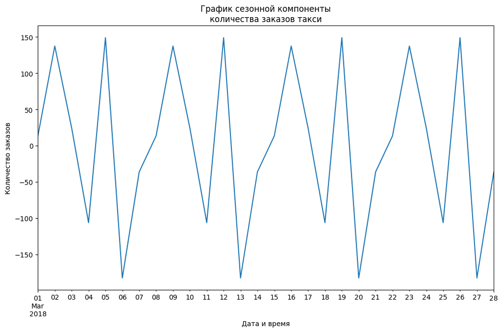

```python
decomposed_day.seasonal['2018-03-01':'2018-03-28'].plot()
plt.title('График сезонной компоненты\nколичества заказов такси')
plt.xlabel('Дата и время')
plt.ylabel('Количество заказов')

fig = plt.gcf()            # увеличиваем размеры графика
fig.set_size_inches(12, 7) # увеличиваем размеры графика
plt.show()
```

```python
# определим дни недели, где 0 - ПН, 6 - ВС
resample_day['day_of_week'] = resample_day.index.dayofweek
resample_day['day_of_week']['2018-03-01':'2018-03-28'].head(10)
```

```
datetime
2018-03-01    3
2018-03-02    4
2018-03-03    5
2018-03-04    6
2018-03-05    0
2018-03-06    1
2018-03-07    2
2018-03-08    3
2018-03-09    4
2018-03-10    5
Freq: D, Name: day_of_week, dtype: int64
```

Максимальное число заказов наблюдается в ПН и ПТ, минимальное число во ВТ, так же наблюдается значительное падение заказов в ВС.

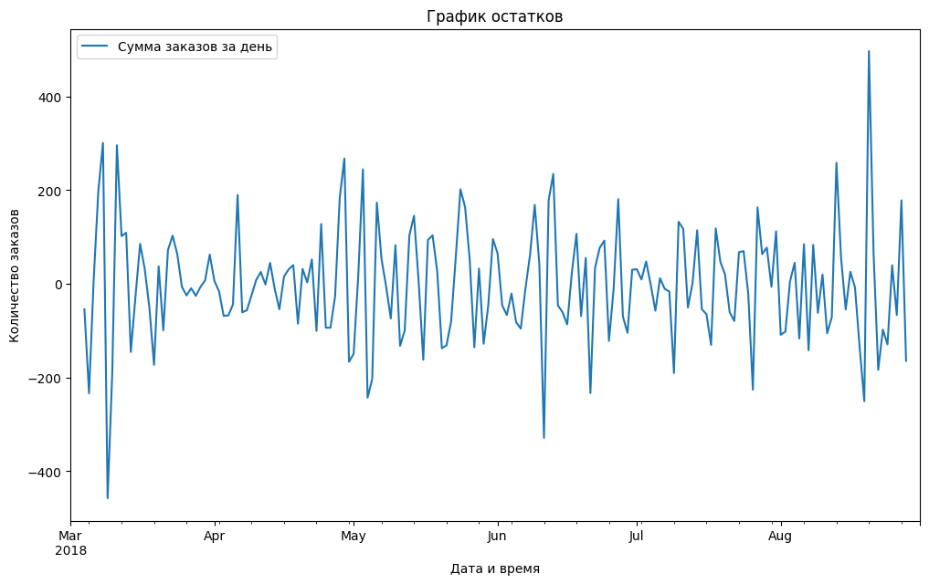

```python
decomposed_day.resid.plot()
plt.title('График остатков')
plt.xlabel('Дата и время')
plt.ylabel('Количество заказов')
plt.legend(['Сумма заказов за день'])

fig = plt.gcf()            # увеличиваем размеры графика
fig.set_size_inches(12, 7) # увеличиваем размеры графика
plt.show()
```

**Вывод:**

- Наблюдаем восходящий тренд - сумма заказов за час и за день растёт. С августа наблюдаем ускорение - квадратичный тренд.
- Недельное стандартное отклонение растёт, дисперсия непостоянна.
- Максимальное дневное число заказов наблюдается в ПН и ПТ, минимальное число во ВТ, так же наблюдается значительное падение заказов в ВС.
- Максимальное часовое число заказов наблюдается в полночь, далее спад примерно до 6 часов утра.
- Остатки на часовом графике распределены неравномерно, начиная с августа доля остатков растет. Следовательно ожидаем большее (по сравнению с другими задачами машинного обучения) расхождение между метриками для обучающей и тестовой выборки.
- Остатки на дневном графике распределены более равномерно.

## Подготовка данных

Подгововим данные для обучения моделей:

- создадим дополнительные признаки.
- разделим данные на тренировочную и тестовую выборки. На тестовую выборку выделим 10% данных.
- Создадим пайплайны для обучения.

```python
# удаляем из датафрейма столбцы, которых не должно быть в обучающих выборках
try:
    resample_hour = resample_hour.drop(['rolling_mean_168', 'std_168'], axis=1)
except:
    pass
```

```python
# напишем функцию для создания признаков
def make_features(df, max_lag, rolling_mean_size_list):
    # coздадим признаки, в которых хранятся день недели т.п., как числа
    df['dayofweek'] = df.index.dayofweek
    df['day'] = df.index.day

    # создаем признаки с отстающими значениями
    for lag in range(1, max_lag + 1):
        df['lag_{}'.format(lag)] = df['num_orders'].shift(lag)

    # создаем признаки со скользящими средними
    for i in rolling_mean_size_list:
        df['rolling_mean_{}'.format(i)] = (df['num_orders']
                                .rolling(i, closed='left')
                                .mean())

make_features(resample_hour, 50, [12, 24, 48])
```

```python
resample_hour.head()
```

| datetime | num_orders | dayofweek | day | lag_1 | lag_2 | lag_3 | lag_4 | lag_5 | lag_6 | lag_7 | ... | lag_44 | lag_45 | lag_46 | lag_47 | lag_48 | lag_49 | lag_50 | rolling_mean_12 | rolling_mean_24 | rolling_mean_48 |
| --- | --- | --- | --- | --- | --- | --- | --- | --- | --- | --- | --- | --- | --- | --- | --- | --- | --- | --- | --- | --- | --- |
| 2018-03-01 00:00:00 | 124 | 3 | 1 | NaN | NaN | NaN | NaN | NaN | NaN | NaN | ... | NaN | NaN | NaN | NaN | NaN | NaN | NaN | NaN | NaN | NaN |
| 2018-03-01 01:00:00 | 85 | 3 | 1 | 124.0 | NaN | NaN | NaN | NaN | NaN | NaN | ... | NaN | NaN | NaN | NaN | NaN | NaN | NaN | NaN | NaN | NaN |
| 2018-03-01 02:00:00 | 71 | 3 | 1 | 85.0 | 124.0 | NaN | NaN | NaN | NaN | NaN | ... | NaN | NaN | NaN | NaN | NaN | NaN | NaN | NaN | NaN | NaN |
| 2018-03-01 03:00:00 | 66 | 3 | 1 | 71.0 | 85.0 | 124.0 | NaN | NaN | NaN | NaN | ... | NaN | NaN | NaN | NaN | NaN | NaN | NaN | NaN | NaN | NaN |
| 2018-03-01 04:00:00 | 43 | 3 | 1 | 66.0 | 71.0 | 85.0 | 124.0 | NaN | NaN | NaN | ... | NaN | NaN | NaN | NaN | NaN | NaN | NaN | NaN | NaN | NaN |

5 rows × 56 columns

```python
# разобьем датасет на обучающую и тестовую выборку.
train, test = train_test_split(resample_hour, shuffle=False, test_size=TEST_SIZE)

# удалим строки с пропусками
train = train.dropna()

# выделим входные и целевой признак для выборок
X_train = train.drop('num_orders', axis=1)
y_train = train['num_orders']
X_test = test.drop('num_orders', axis=1)
y_test = test['num_orders']

# количественные признаки - это все столбцы тренировочной выборки
num_columns = list(X_train.columns)
```

```python
# выведем обучающую выборку
print(X_train.shape)
X_train.head()
```

```
(3924, 55)
```

| datetime | dayofweek | day | lag_1 | lag_2 | lag_3 | lag_4 | lag_5 | lag_6 | lag_7 | lag_8 | ... | lag_44 | lag_45 | lag_46 | lag_47 | lag_48 | lag_49 | lag_50 | rolling_mean_12 | rolling_mean_24 | rolling_mean_48 |
| --- | --- | --- | --- | --- | --- | --- | --- | --- | --- | --- | --- | --- | --- | --- | --- | --- | --- | --- | --- | --- | --- |
| 2018-03-03 02:00:00 | 5 | 3 | 108.0 | 163.0 | 72.0 | 119.0 | 101.0 | 93.0 | 49.0 | 89.0 | ... | 12.0 | 6.0 | 43.0 | 66.0 | 71.0 | 85.0 | 124.0 | 88.500000 | 65.291667 | 61.083333 |
| 2018-03-03 03:00:00 | 5 | 3 | 25.0 | 108.0 | 163.0 | 72.0 | 119.0 | 101.0 | 93.0 | 49.0 | ... | 15.0 | 12.0 | 6.0 | 43.0 | 66.0 | 71.0 | 85.0 | 86.916667 | 63.208333 | 60.125000 |
| 2018-03-03 04:00:00 | 5 | 3 | 64.0 | 25.0 | 108.0 | 163.0 | 72.0 | 119.0 | 101.0 | 93.0 | ... | 34.0 | 15.0 | 12.0 | 6.0 | 43.0 | 66.0 | 71.0 | 87.333333 | 63.208333 | 60.083333 |
| 2018-03-03 05:00:00 | 5 | 3 | 44.0 | 64.0 | 25.0 | 108.0 | 163.0 | 72.0 | 119.0 | 101.0 | ... | 69.0 | 34.0 | 15.0 | 12.0 | 6.0 | 43.0 | 66.0 | 84.166667 | 64.208333 | 60.104167 |
| 2018-03-03 06:00:00 | 5 | 3 | 15.0 | 44.0 | 64.0 | 25.0 | 108.0 | 163.0 | 72.0 | 119.0 | ... | 64.0 | 69.0 | 34.0 | 15.0 | 12.0 | 6.0 | 43.0 | 78.500000 | 64.375000 | 60.291667 |

5 rows × 55 columns

```python
print(y_train.shape)
y_train.head()
```

```
(3924,)
```

```
datetime
2018-03-03 02:00:00    25
2018-03-03 03:00:00    64
2018-03-03 04:00:00    44
2018-03-03 05:00:00    15
2018-03-03 06:00:00     9
Freq: H, Name: num_orders, dtype: int64
```

```python
# создаём пайплайн для подготовки данных
data_preprocessor = ColumnTransformer(
    [
        ('num', StandardScaler(), num_columns) # масштабируем количественные признаки
    ],
    remainder='passthrough'
)

# создаём итоговый пайплайн: подготовка данных и модель
pipe_final = Pipeline([
    ('preprocessor', data_preprocessor),
    ('models', LinearRegression())
])
```

**Вывод:**

Подготовка данных выполнена. Приступаем к обучению моделей.

## Обучение моделей

Обучим три модели:

1. Модель линейной регрессии LinearRegression;
2. Модель градиентного бустинга LightGBM;
3. Модель дерева решений DecisionTree.
- Целевой признак: `num_orders`.
- Для выбора лучшей модели будем считать метрику RMSE. Значение метрики RMSE должно быть не больше 48.

```python
# перебираем гиперпараметры моделей
param_grid = [


    # словарь для модели LinearRegression()
    {
        'models': [LinearRegression()],
        'preprocessor__num': [StandardScaler(), MinMaxScaler(), 'passthrough']

    },


    # словарь для модели DecisionTreeRegressor()
    {
        'models': [DecisionTreeRegressor(random_state=RANDOM_STATE)],
        'models__criterion': ['squared_error'],
        'models__max_depth': range(2, 5),
        'models__max_features': range(2, 5),
        'preprocessor__num': [StandardScaler(), MinMaxScaler(), 'passthrough']
    },


     # словарь для модели LGBMRegressor()
    {
        'models': [LGBMRegressor(random_state=RANDOM_STATE)],
        'models__boosting_type': ['gbdt',
                                  'dart'],
        'preprocessor__num': [StandardScaler(), MinMaxScaler(), 'passthrough']
    },
]
```

```python
%%time

# создаем объект для перекрестной проверки временных рядов
tscv = TimeSeriesSplit(gap=0, n_splits=5)

model = RandomizedSearchCV(
    pipe_final,
    param_grid,
    cv=tscv,
    scoring='neg_mean_squared_error',
    random_state=RANDOM_STATE,
    n_jobs=-1)

model.fit(X_train, y_train)
```

```
[LightGBM] [Info] Auto-choosing col-wise multi-threading, the overhead of testing was 0.001671 seconds.
You can set `force_col_wise=true` to remove the overhead.
[LightGBM] [Info] Total Bins 10266
[LightGBM] [Info] Number of data points in the train set: 3924, number of used features: 55
[LightGBM] [Info] Start training from score 78.487768
CPU times: total: 1.56 s
Wall time: 9.15 s
```

```
RandomizedSearchCV(cv=TimeSeriesSplit(gap=0, max_train_size=None, n_splits=5, test_size=None),
                   estimator=Pipeline(steps=[('preprocessor',
                                              ColumnTransformer(remainder='passthrough',
                                                                transformers=[('num',
                                                                               StandardScaler(),
                                                                               ['dayofweek',
                                                                                'day',
                                                                                'lag_1',
                                                                                'lag_2',
                                                                                'lag_3',
                                                                                'lag_4',
                                                                                'lag_5',
                                                                                'lag_6',
                                                                                'lag_7',
                                                                                'lag_8',
                                                                                'lag_9',
                                                                                'lag_10',
                                                                                'lag_11',
                                                                                'lag_12',
                                                                                'lag_13',
                                                                                'lag_14',
                                                                                '...
                                         'models__criterion': ['squared_error'],
                                         'models__max_depth': range(2, 5),
                                         'models__max_features': range(2, 5),
                                         'preprocessor__num': [StandardScaler(),
                                                               MinMaxScaler(),
                                                               'passthrough']},
                                        {'models': [LGBMRegressor(random_state=42)],
                                         'models__boosting_type': ['gbdt',
                                                                   'dart'],
                                         'preprocessor__num': [StandardScaler(),
                                                               MinMaxScaler(),
                                                               'passthrough']}],
                   random_state=42, scoring='neg_mean_squared_error')
```

## Анализ моделей

```python
# отображаем всё содержимое ячеек
pd.set_option('display.max_colwidth', None)

# выводим из списка параметры лучшей модели
cv_results =  pd.DataFrame(model.cv_results_).sort_values('rank_test_score', ascending=1)

print('Лучшая модель:')
cv_results[cv_results['rank_test_score']== 1].set_index('param_models').T
```

```
Лучшая модель:
```

| param_models | LGBMRegressor(random_state=42) |
| --- | --- |
| mean_fit_time | 1.543396 |
| std_fit_time | 0.087028 |
| mean_score_time | 0.010806 |
| std_score_time | 0.000403 |
| param_preprocessor__num | MinMaxScaler() |
| param_models__boosting_type | gbdt |
| param_models__max_features | NaN |
| param_models__max_depth | NaN |
| param_models__criterion | NaN |
| params | {'preprocessor__num': MinMaxScaler(), 'models__boosting_type': 'gbdt', 'models': LGBMRegressor(random_state=42)} |
| split0_test_score | -484.793451 |
| split1_test_score | -483.137234 |
| split2_test_score | -512.716296 |
| split3_test_score | -559.364236 |
| split4_test_score | -968.286069 |
| mean_test_score | -601.659457 |
| std_test_score | 185.375309 |
| rank_test_score | 1 |

```python
print ('Метрика RMSE лучшей модели на кросс-валидации:'
       , round(sqrt(abs(model.best_score_))))
```

```
Метрика RMSE лучшей модели на кросс-валидации: 25
```

Проверим лучшую модель на тестовой выборке

```python
y_pred = model.predict(X_test)
rmse = round(mean_squared_error(y_test, y_pred, squared=False))
print('Метрика RMSE лучшей модели на тестовой выборке:', rmse)
```

```
Метрика RMSE лучшей модели на тестовой выборке: 40
```

**Вывод:**

Лучшая модель - **LGBMRegressor**:

- RMSE на тестовой выборке: 40 заказов.

## Выводы

**Цель проекта:**

Компания такси собрала исторические данные о заказах такси в аэропортах. Чтобы привлекать больше водителей в период пиковой нагрузки, нужно спрогнозировать количество заказов такси на следующий час и построить модель для такого предсказания. Значение метрики *RMSE* на тестовой выборке должно быть не больше 48.

**В ходе проекта мы провели следующую работу:**

- изучили данные, проверили их на предмет аномалий и несоответствий;
- произвели исследовательский анализ.
- подготовили данные и обучили 3 модели для решения задачи регрессии (прогноз количества заказов такси на следующий час):
- выбрали лучшую модель по заданному критерию и протестировали на тестовой выборке.

**Результаты:**

Лучшая модель - **LGBMRegressor**:

- RMSE на тестовой выборке: 40 заказов, что удовлетворяет требованиям заказчика.